# Communicate Data Findings: Loans Data Explanatory Analysis

### *by `Owhonda Moses`*

## Investigation Overview

In this investigation, I wanted to summarize the characteristics of features that can affect the annual percentage rate (APR) and outcome of a loan. The main focus was on Credit score, Borrower APR, Income, Prosper Score, Loan Status and Loan Amount.

## Dataset Overview

The original dataset consisted of 113,937 loans with 81 variables on each loan. Prosper score was used as a criteria to subset the dataframe, which reduced the dataset to 84,853 loans with 14 data points selected for the analysis.

## Distribution of Credit Score Ranges

> Credit score peaks between 660 - 719 with the most frequent range between 660 - 679. There is a slight right skew in the distribution with higher credit scores having less borrowers.

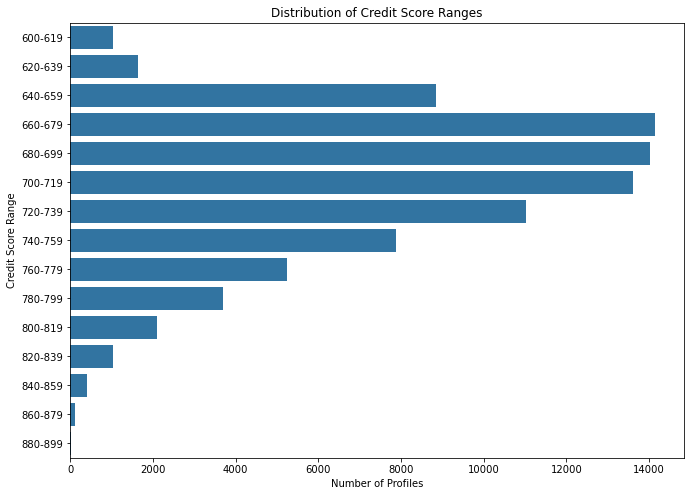

## Distribution of Annual Percentage Rates

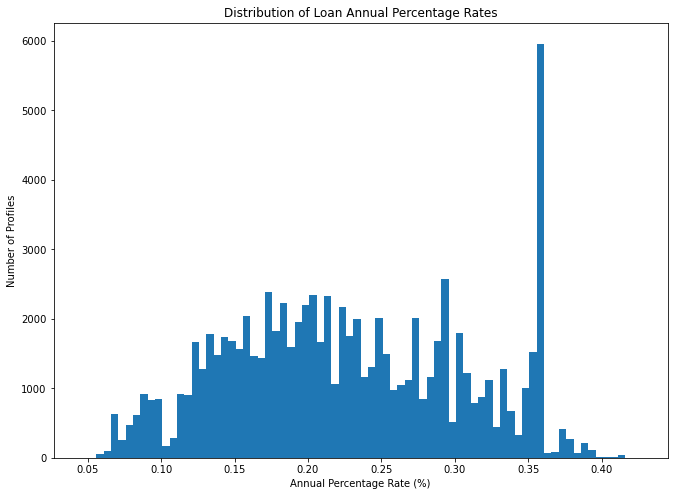

## Distribution of Income Ranges

> Income ranges peak within `$50,000 - $74,999`, followed by the `$25,000 - $49,999` range, and we see that folks with $0 income are among the least borrowers.

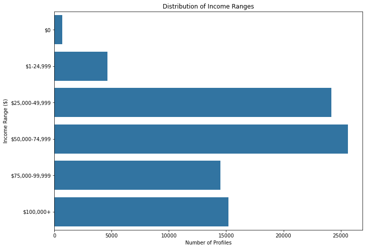

## Distribution of Prosper Score

> Most of the borrowers have a Prosper score of 4.0, 6.0 and 8.0. We see borrowers with the lowest Prosper score of 1.0 accessed the least number of loans.

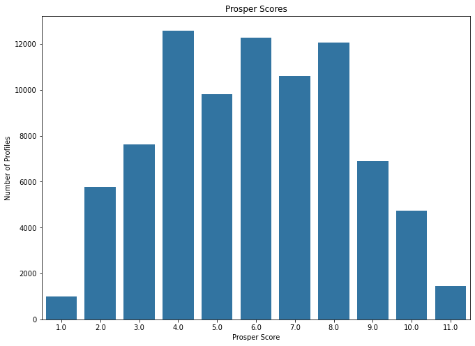

## Credit Score Range vs Income Range

> A lot of credit profiles in the credit score peak range of 660-699 earn between `$25,000-$74,999`. Generally, the frequency of income earners on a loan decreases with increasing credit scores

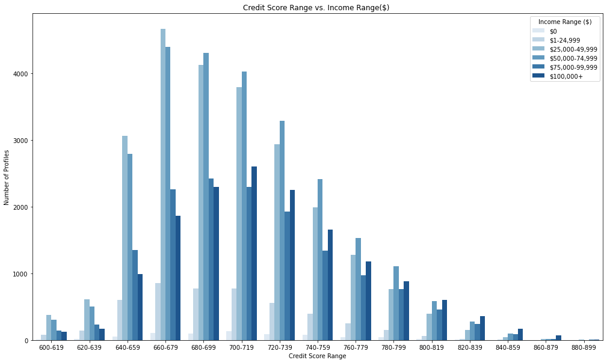

## Credit Score Range vs Annual Percentage Rate

> In increasing order of credit score ranges, there are steady reductions in annual percentage rates, which could be one of the perks of having a higher credit score.

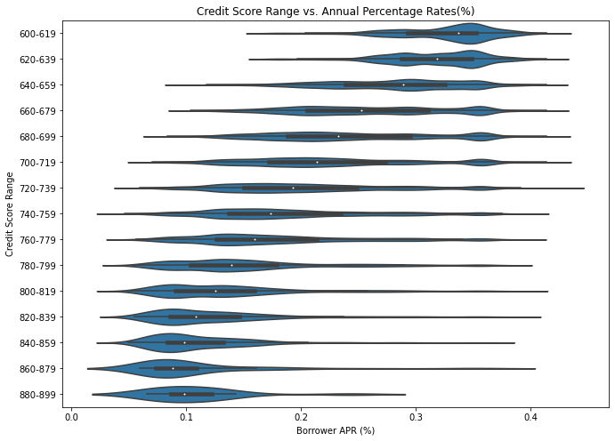

## Credit Score Range vs Prosper Score

> Slight positive correlation is observed between Credit score range and prosper score. The highest prosper scores seem to lie predominantly between the credit score range of 700 - 799.

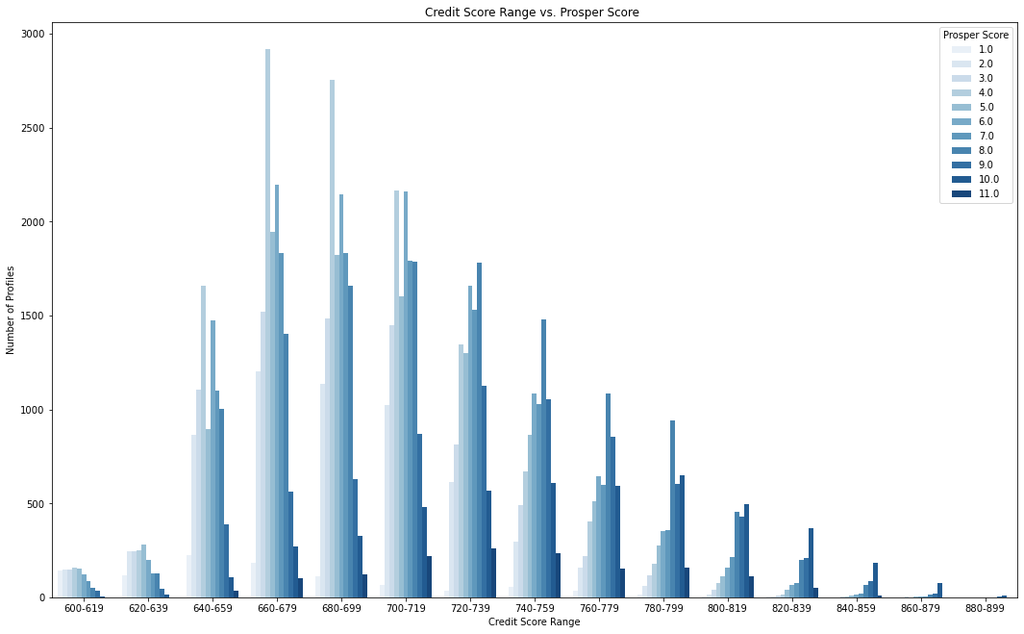

## Credit Score Range and Borrower APR by Income Range

> There is an interaction effect between credit score range, borrower annual percentage rates and income range. Income range strengthens the negative relationship between the main features. It is highly suggested that borrowers with lesser income seem to incur higher annual percentage rates on their loans with `$0` income earners having the highest APRs.

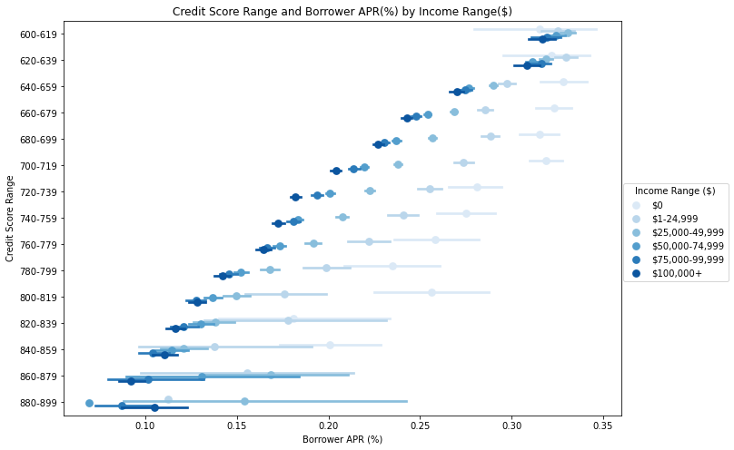

## Credit Score Range and Borrower APR by Loan Status

> The staggering high number of currently active loans obscured insights into the other loan status and so it was excluded from this visuals. We see that most loans that were either delinquent, defaulted or charged off had higher annual percentage rates and credit profiles with high credit scores between 840-899 seldom had delinquent or defaulted loans.

[figure not shown]

## Credit Score Range and Borrower APR by Loan Amount

> From our scatterplot, we see that larger loan amounts attracted better rates, and the majority of loans with smaller amounts lied around the 30%-40% annual percentage rates. We also see that borrowers with a credit score higher than 740 accessed much larger loans.

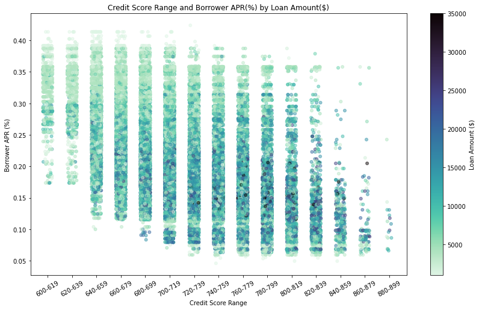